# Lab1

Michael McCormack

February 3, 2018

## Intro

For this project we used spam data from the kernlab package. This data seems to be a data regarding Spam e-mail data. More specifically,this is a data set collected at Hewlett-Packard Labs, that classifies 4601 e-mails as spam or non-spam. In addition to this class label there are 57 variables indicating the frequency of certain words and characters in the e-mail. Below is a summary of the spam data.

```r
##Loading Appropriate data
data(spam)

x <- head(spam)
##Shows first 6 instances of the data
print(x)
```

```
##   make address  all num3d  our over remove internet order mail receive
## 1 0.00    0.64 0.64     0 0.32 0.00   0.00     0.00  0.00 0.00    0.00
## 2 0.21    0.28 0.50     0 0.14 0.28   0.21     0.07  0.00 0.94    0.21
## 3 0.06    0.00 0.71     0 1.23 0.19   0.19     0.12  0.64 0.25    0.38
## 4 0.00    0.00 0.00     0 0.63 0.00   0.31     0.63  0.31 0.63    0.31
## 5 0.00    0.00 0.00     0 0.63 0.00   0.31     0.63  0.31 0.63    0.31
## 6 0.00    0.00 0.00     0 1.85 0.00   0.00     1.85  0.00 0.00    0.00
##   will people report addresses free business email  you credit your font
## 1 0.64   0.00   0.00      0.00 0.32     0.00  1.29 1.93   0.00 0.96    0
## 2 0.79   0.65   0.21      0.14 0.14     0.07  0.28 3.47   0.00 1.59    0
## 3 0.45   0.12   0.00      1.75 0.06     0.06  1.03 1.36   0.32 0.51    0
## 4 0.31   0.31   0.00      0.00 0.31     0.00  0.00 3.18   0.00 0.31    0
## 5 0.31   0.31   0.00      0.00 0.31     0.00  0.00 3.18   0.00 0.31    0
## 6 0.00   0.00   0.00      0.00 0.00     0.00  0.00 0.00   0.00 0.00    0
##   num000 money hp hpl george num650 lab labs telnet num857 data num415
```

[output cut: 34 more lines]

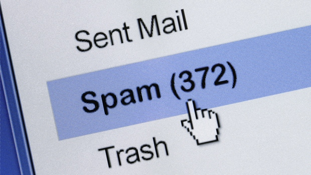

https://images.techhive.com/images/article/2016/06/spam_email_screen_stock-100664936-large.jpg

## Summary of Data

```r
delayedAssign("x", spam)
myvars <- c('charDollar','charExclamation','type')
newdata <- subset(x, select = myvars)
head(newdata)
```

```
##   charDollar charExclamation type
## 1      0.000           0.778 spam
## 2      0.180           0.372 spam
## 3      0.184           0.276 spam
## 4      0.000           0.137 spam
## 5      0.000           0.135 spam
## 6      0.000           0.000 spam
```

```r
summary(newdata)
```

```
##    charDollar      charExclamation        type
##  Min.   :0.00000   Min.   : 0.0000   nonspam:2788
##  1st Qu.:0.00000   1st Qu.: 0.0000   spam   :1813
##  Median :0.00000   Median : 0.0000
##  Mean   :0.07581   Mean   : 0.2691
##  3rd Qu.:0.05200   3rd Qu.: 0.3150
##  Max.   :6.00300   Max.   :32.4780
```

```r
#Intermediate Part
grouped_summary <- newdata %>%
  select(charDollar,charExclamation, type) %>%
  group_by(type) %>%
  summarise( dollar = mean(charDollar), exclamation = mean(charExclamation))

dollar_mean <- grouped_summary$dollar

grouped_summary
```

```
## # A tibble: 2 x 3
##   type    dollar exclamation
##   <fct>    <dbl>       <dbl>
## 1 nonspam 0.0116       0.110
## 2 spam    0.174        0.514
```

I chose the variables charExclamation because I have always associated Exclamation marks in e-mails that are spam, so I’d expect spam emails to have a higher exclamation rate. I chose the type variable because it is the response variable that will be used in logistic regression. It classifies the emails as either spam or not - this variable will also be beneficial in the initial plotting of our data. I chose the variable charDollar, because I have always associated spam emails as having more dollar signs in them.

It is very interesting to compare the dollar and exclamation means for the grouped summaries. Comparing the means of dollar sign rate and exclamation sign rate for the spam and nonspam groups we find that the spam group - as expected - has higher rates of both dollar signs and exclamation marks. Specifically the mean for dollar signs in the spam category was 14.9786075 times higher than the nonspam category. Additionally the mean for exclamation marks for the spam group was 4.6708154 times higher than the nonspam group.

#### Quick EDA

```r
#Removing null values - However because there are 0 null values this step is not important in this dataset - however in theory it is always important to deal with nonperfect data
clean <- newdata %>%
  na.omit()
```

### Plotting

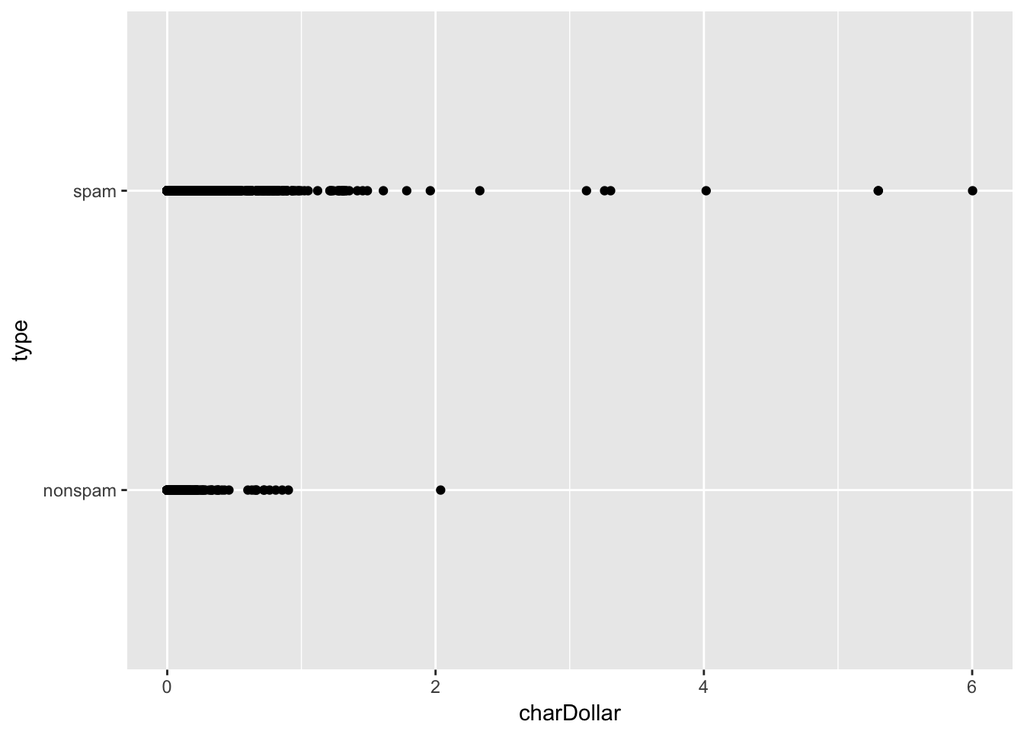

```r
#Initial plots
ggplot(data = newdata, aes(charDollar, type)) + geom_point()
```

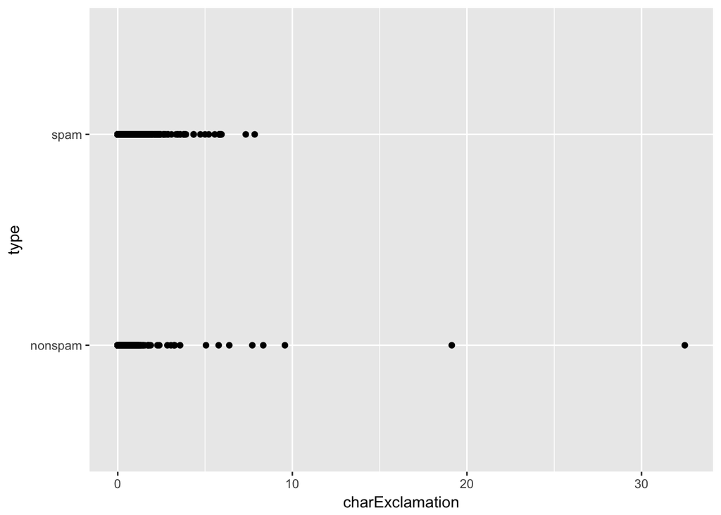

```r
ggplot(data = newdata, aes(charExclamation, type)) + geom_point()
```

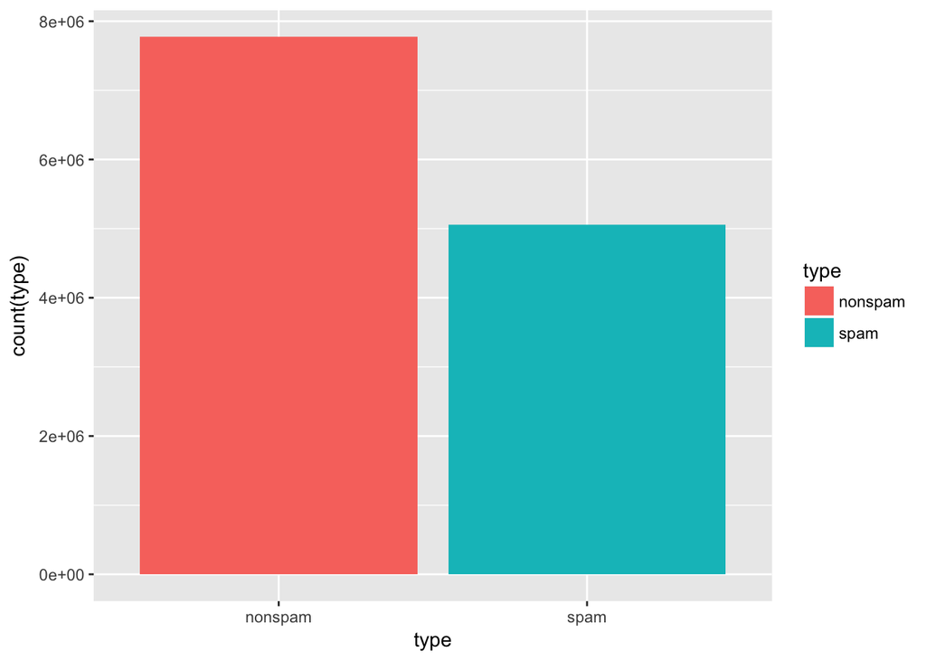

```r
ggplot(data = newdata, aes(x = type,y =count(type), fill = type)) + geom_bar(stat="identity")
```

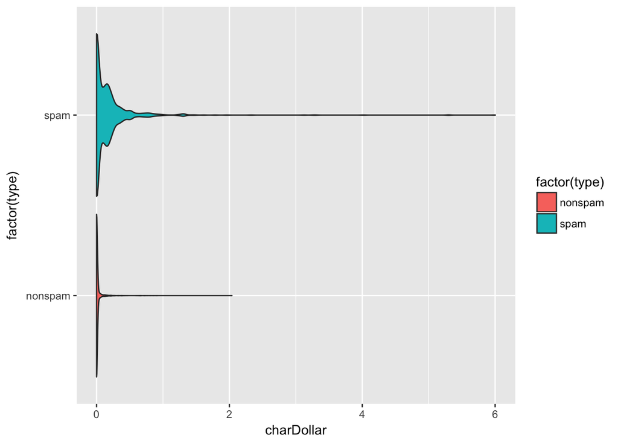

```r
# Violin Plots
# Scale maximum width to 1 for all violins:
ggplot(data = newdata, aes(factor(type),charDollar)) + geom_violin(scale = "width", aes(fill = factor(type))) + coord_flip()
```

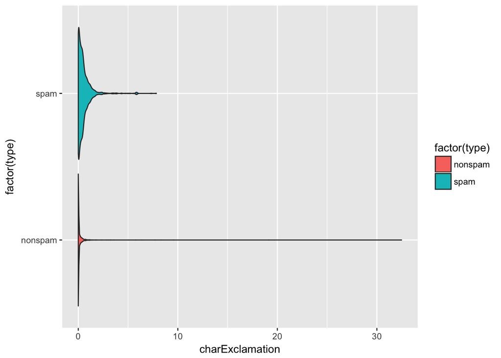

```r
ggplot(data = newdata, aes(factor(type),charExclamation)) + geom_violin(scale = "width", aes(fill = factor(type))) + coord_flip()
```

## Data Analysis

```r
set.seed(1)
#Splitting data into training and test sets
# By default R comes with few datasets.
data = newdata
dim(data) #4601    3
```

```
## [1] 4601    3
```

```r
clean_data <- data %>%
  mutate(type = ifelse(type == "spam", 1,0))



#Sample Indexes
indexes = sample(1:nrow(clean_data), size=0.2*nrow(clean_data))

# Split data
test = clean_data[indexes,]
dim(test)  # 920 3
```

```
## [1] 920   3
```

```r
train = clean_data[-indexes,]
dim(train) # 3681 3
```

```
## [1] 3681    3
```

```r
model <- glm(formula = type ~ ., family = binomial(link = "logit"),
    data = train)
summary(model)
```

```
##
## Call:
## glm(formula = type ~ ., family = binomial(link = "logit"), data = train)
##
## Deviance Residuals:
##     Min       1Q   Median       3Q      Max
## -8.4904  -0.6683  -0.6683   0.6800   1.7937
##
## Coefficients:
##                 Estimate Std. Error z value Pr(>|z|)
## (Intercept)     -1.38543    0.05047  -27.45   <2e-16 ***
## charDollar      13.12293    0.68171   19.25   <2e-16 ***
## charExclamation  1.56599    0.12274   12.76   <2e-16 ***
## ---
## Signif. codes:  0 '***' 0.001 '**' 0.01 '*' 0.05 '.' 0.1 ' ' 1
##
## (Dispersion parameter for binomial family taken to be 1)
##
##     Null deviance: 4936.0  on 3680  degrees of freedom
## Residual deviance: 3625.8  on 3678  degrees of freedom
## AIC: 3631.8
##
## Number of Fisher Scoring iterations: 25
```

```r
anova(model)
```

```
## Analysis of Deviance Table
##
## Model: binomial, link: logit
##
## Response: type
##
## Terms added sequentially (first to last)
##
##
##                 Df Deviance Resid. Df Resid. Dev
## NULL                             3680     4936.0
## charDollar       1  1034.69      3679     3901.3
## charExclamation  1   275.46      3678     3625.8
```

```r
fitted.results <- predict(model,test,type='response')
fitted.results <- ifelse(fitted.results > 0.5,1,0)
misClasificError <- mean(fitted.results != test$type)
#Determining Overall Accuracy
print(paste('Accuracy',1-misClasificError))
```

```
## [1] "Accuracy 0.822826086956522"
```

```r
#Determining AUC
roc_obj <- roc(test$type,fitted.results)
auc(roc_obj)
```

```
## Area under the curve: 0.7856
```

It seems as though this model is accurate about 82% of the time. Additionally, the AUC was determined to be 78.56%.

AUC is often predicted over accuracy for binary classification for a number of different reasons. AUC stands for Area Under the Curve - the curve reffering to the ROC curve. ROC stands for Receiver Operating Characteristic. The implicit goal of AUC is to deal with situations where you have a very skewed sample distribution, and don’t want to overfit to a single class.

What you’re actually getting when you do an AUC over accuracy is something that will strongly discourage people going for models that are representative, but not discriminative, as this will only actually select for models that achieve false positive and true positive rates that are significantly above random chance, which is not guaranteed for accuracy.

AUC response adapted from: https://datascience.stackexchange.com/questions/806/advantages-of-auc-vs-standard-accuracy